# Analysis of climate justice literature

# Info

I’m doing an analysis of the literature published on ‘climate justice’, including ‘social justice’, ‘environmental justice’, ‘climate change’, and ‘global warming’. The search terms and query use in the Scopus API were provided by Meg Parsons and returns 1827 results. Meg is interested in most of the standard info like when ‘climate justice’ was first mentioned, how popular the topic has become, who is publishing on it and so on. I’m hoping to delve a little deeper with some text mining analysis. This .rmd is the latest attempt after trying the bibliometrix package approach.

I’d appriciate:

- An eye out for errors (I’m not sure if all the functions do what I expect them too, e.g., lemmatisation, incorrect grouping by article)
  - I think I’m missing a filtering step to remove some poor records like auther name = The Lancet
- Any leads/code/resources on sections I haven’t completed yet marked by empty headers at the end (like plotting the author network)
- Methods of analysing the topic (I’ve seen ordinations on topic analysis)
- Any useful stuff I haven’t thought of doing!

I ditched my first attempt following the bibliometrix package approach and the following draws heavily on [this tutorial](https://bookdown.org/Maxine/tidy-text-mining/tidy-text-format.html). Manually downloaded records from Scopus were not complete or tidy so I took George’s advice and turned to using the API and focusing on Scopus and not Web of Science (at least for now).

# Corpus overview

## What publication types (books, artilces…)

Filter out Notes, Letter, Erratum, Short Survey, Conference Paper, Conference Review?

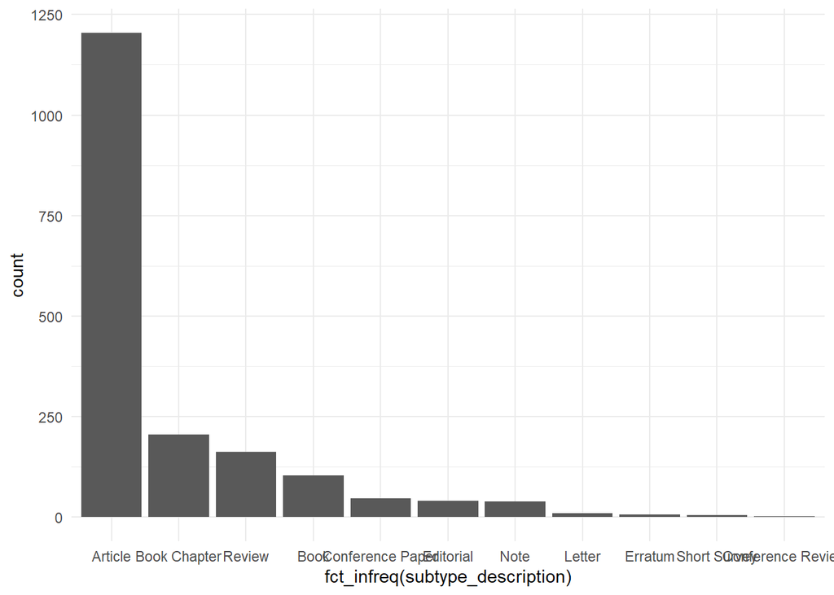

## Top 20 most popular journals

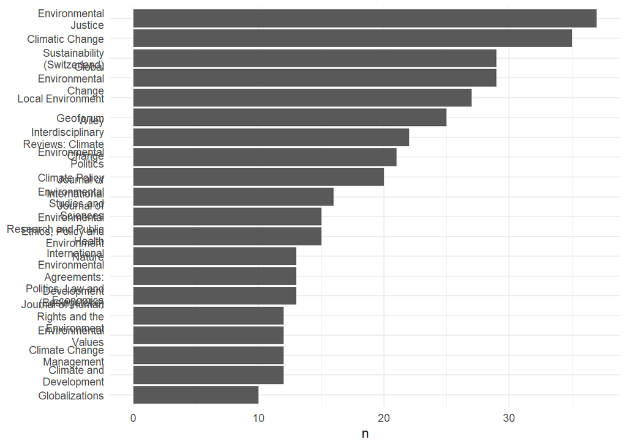

Environmental Justice journal established in March 2008

## Publications through time

I will annotate this with key events like the Kyoto protocol, IPCC publications…

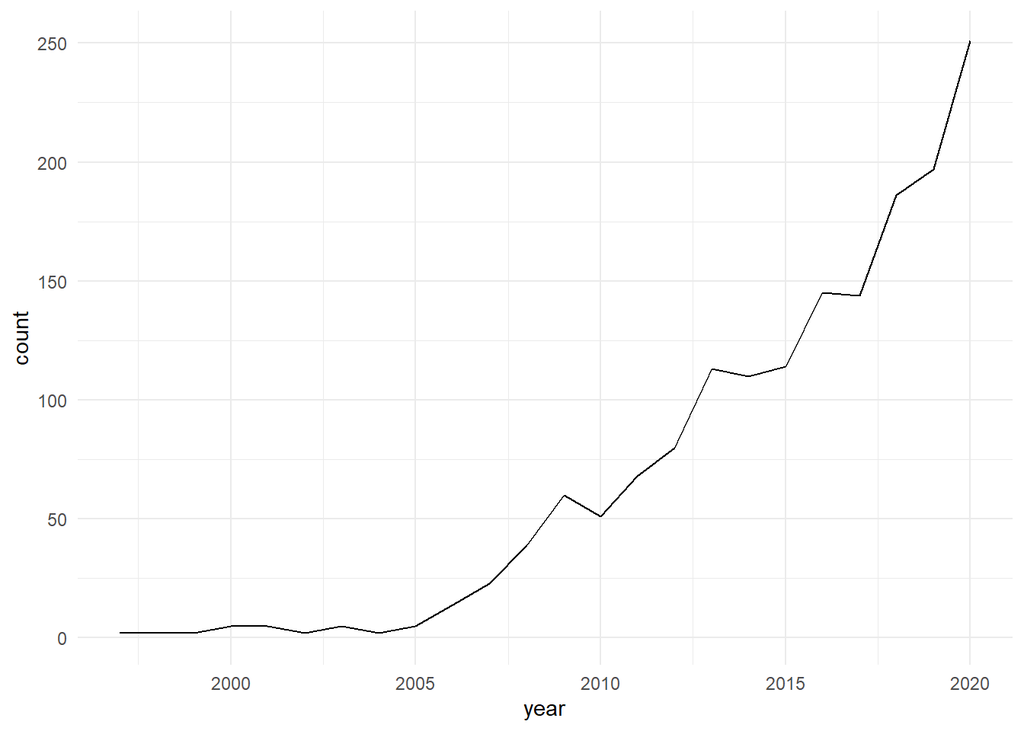

## Mean number of authors through time

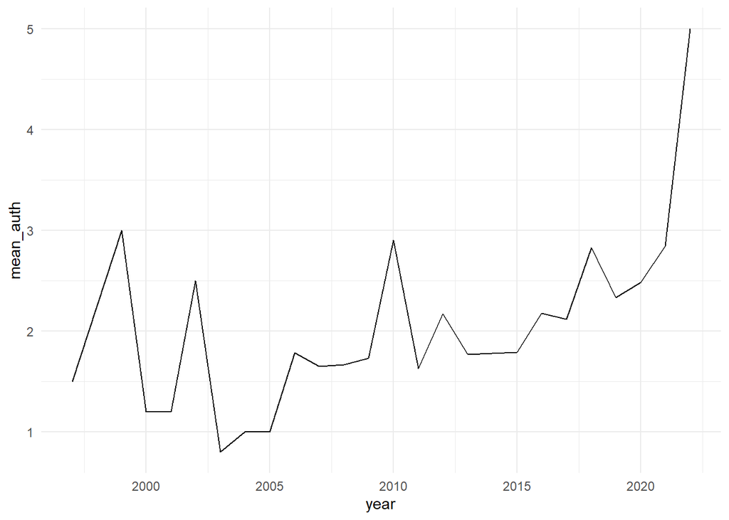

## Most productive authors (first and not)

Issues with duplicate authors? I.e., with/without initials in first name?

```
## [1] 4137   12
```

```
## [1] 28
```

```
## [1] 21
```

```
##        fa  seq                                                    author_url
## 101  <NA> <NA>                                                          <NA>
## 102  <NA> <NA>                                                          <NA>
## 301  <NA> <NA>                                                          <NA>
## 302  <NA> <NA>                                                          <NA>
## 388  true    1 https://api.elsevier.com/content/author/author_id/56213072600
## 549  <NA> <NA>                                                          <NA>
## 966  true    1 https://api.elsevier.com/content/author/author_id/57202121668
## 1682 <NA> <NA>                                                          <NA>
## 1683 <NA> <NA>                                                          <NA>
## 1914 <NA> <NA>                                                          <NA>
## 1969 <NA> <NA>                                                          <NA>
## 2042 <NA> <NA>                                                          <NA>
## 2043 <NA> <NA>                                                          <NA>
## 2408 <NA> <NA>                                                          <NA>
```

[output cut: 72 more lines]

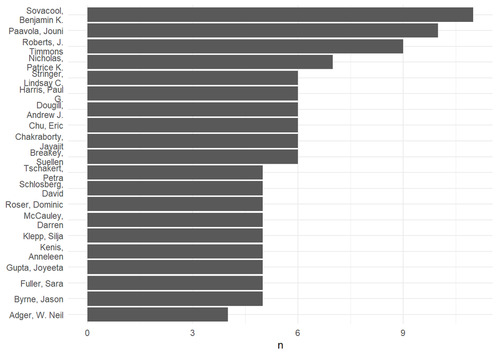

## Jacqui’s suggestion: cleaning author names to handle duplicates by using “Surname, FirstInitial.”

The most common and basic unit we can fall back to is “Surname, FirstInitial.”

NOTE: This assumes that all combinations of names will produce a unique value, this may not always be the case (e.g. Jacqui Vanderhoorn, Jonathan Vanderhoorn)

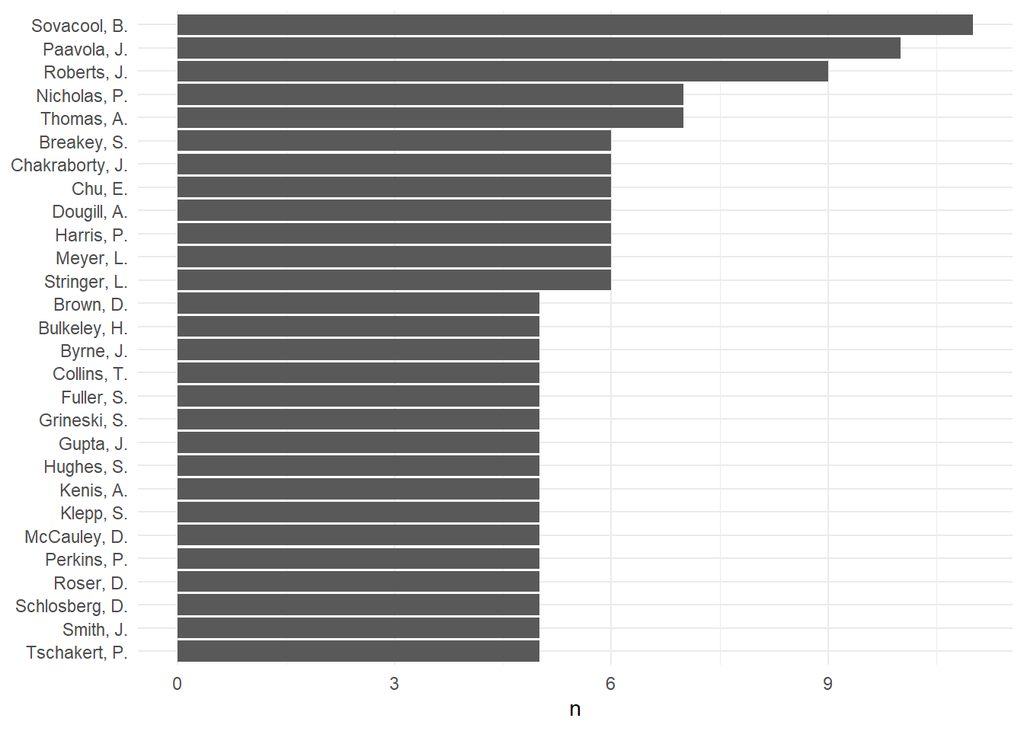

## Most cited papers

```
## [1] 0
```

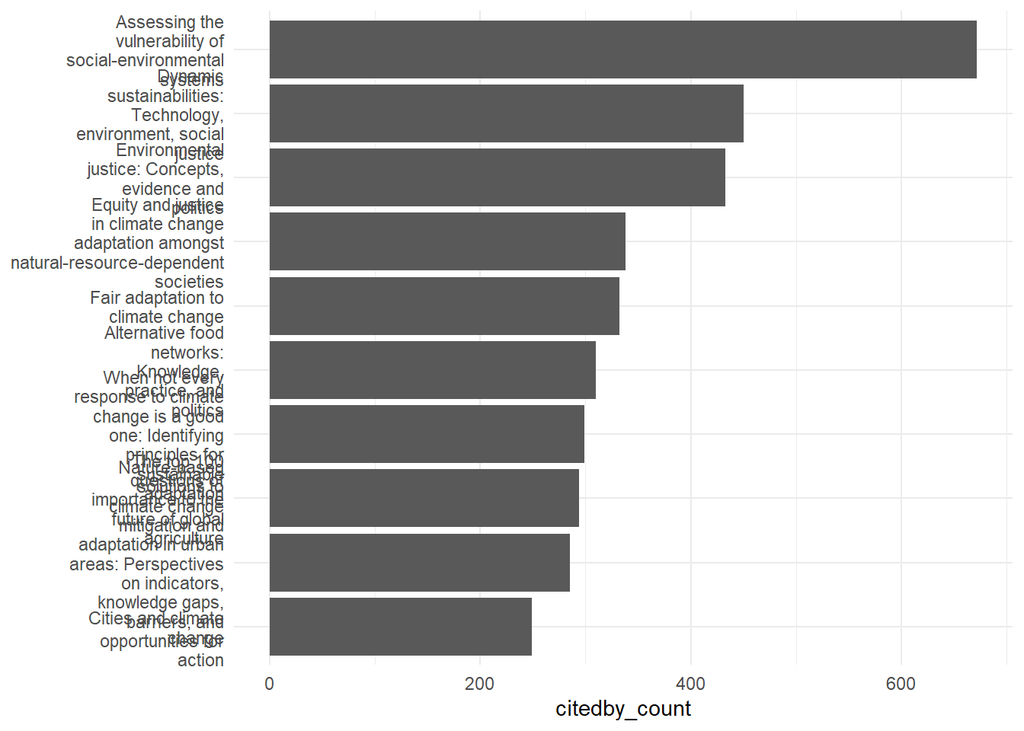

# Corpus analysis

## Most common words in abstracts.

Not surprisingly they match the search terms

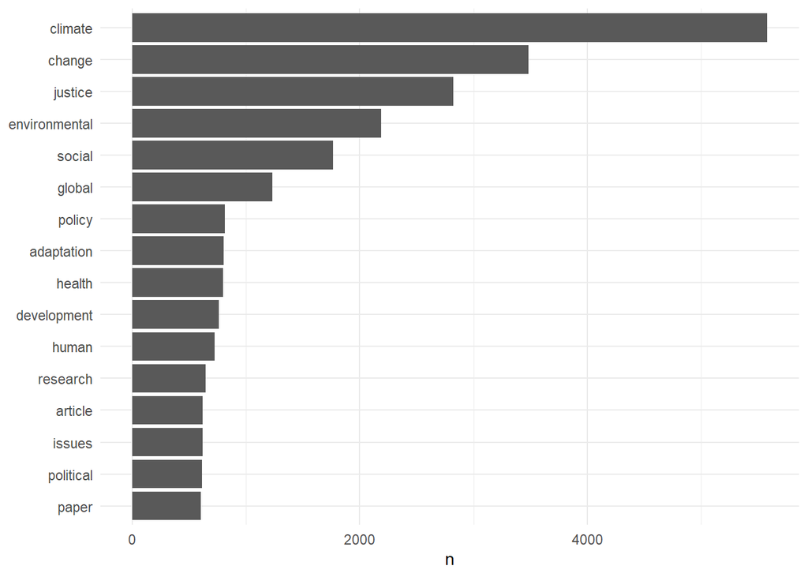

## Most common word pairs in abstracts (again, no surprises)

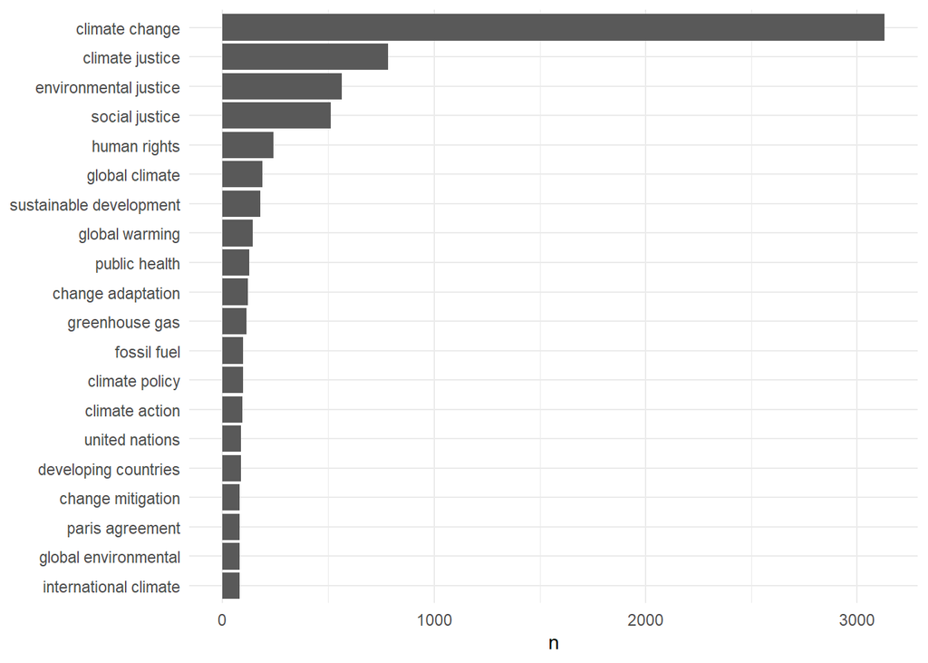

## Network of word pairs

Network graph of most commonly joined words. “Note that this is a visualization of a Markov chain, a common model in text processing, where the choice of a word only depends on its previous word”.

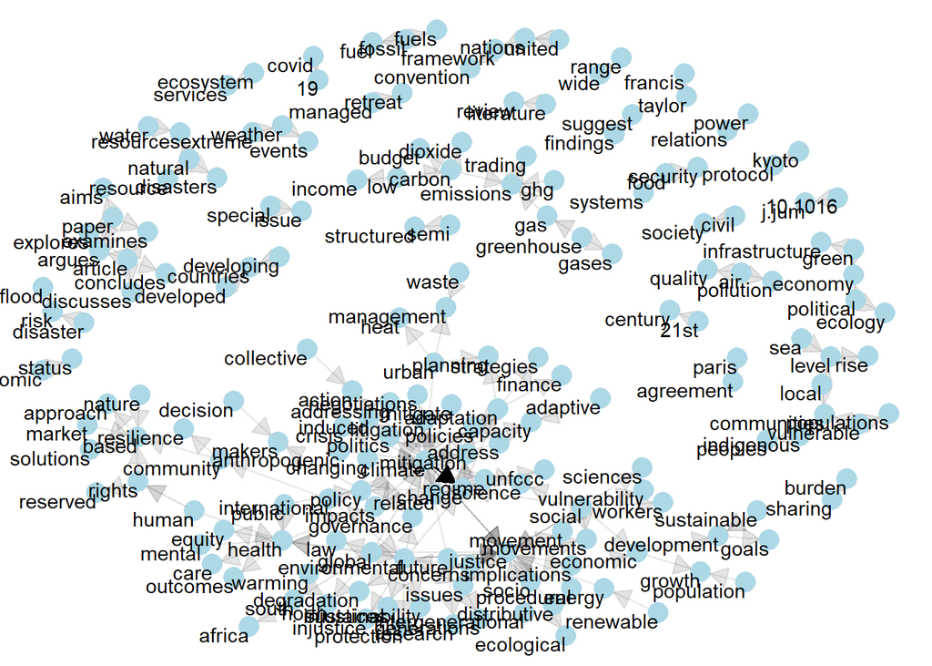

# tf-idf and log ratio

Compares documents, not useful in this case but curious. Maybe can be analysed further? Did not work when applied to all abstracts not grouped by article.

```
## # A tibble: 6 x 7
##   entry_number word                n     tf   idf tf_idf log_odds_weighted
##   <chr>        <chr>           <int>  <dbl> <dbl>  <dbl>             <dbl>
## 1 288          ibid               33 0.0813  7.51  0.610              43.0
## 2 288          p                  31 0.0764  5.72  0.437              47.7
## 3 336          neuroscientists     2 0.0556  7.51  0.417              11.3
## 4 537          ee                  9 0.0489  7.51  0.367              22.5
## 5 590          cbis               12 0.0482  7.51  0.362              25.4
## 6 1305         evacuation          7 0.0526  6.82  0.359              21.3
```

A word cloud (because why not?)

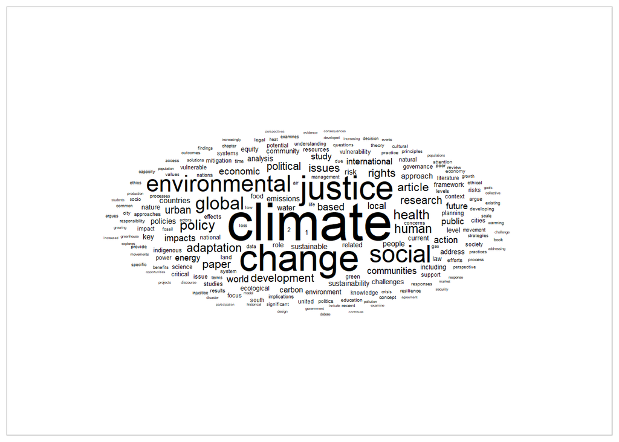

# Correlating word pairs

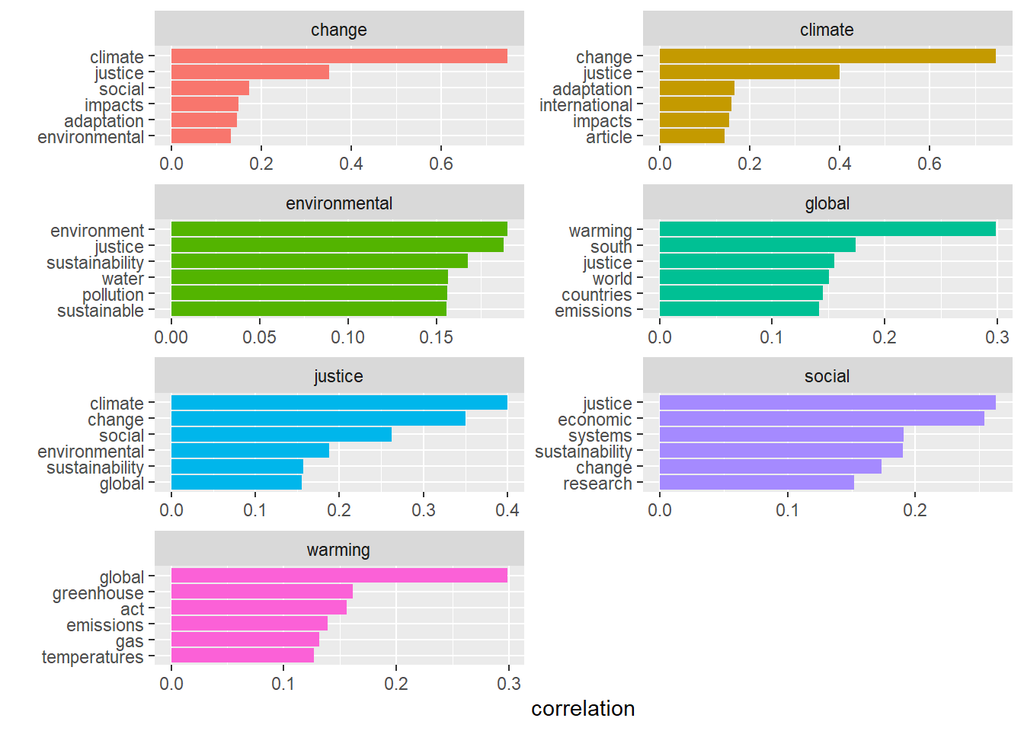

Do I need to do some regex to remove numbers from abstracts? looks like DOIs are in there. Same from grouped bigrams.

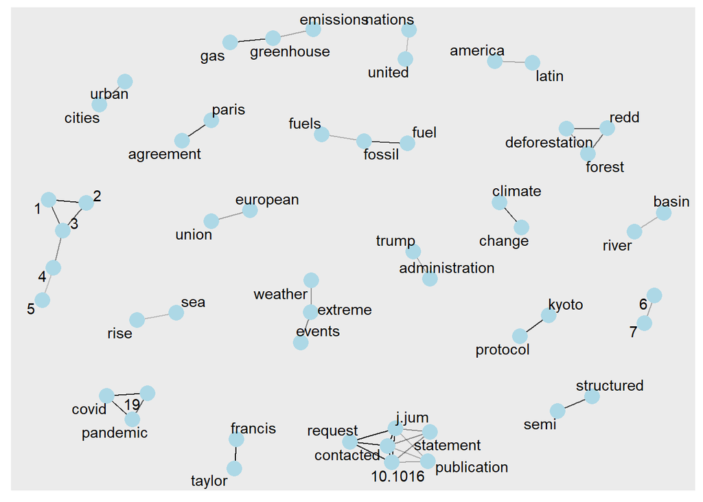

The following is bigrams grouped by article rather than all article abstracts. Probably not useful to analyse per abstract but highlights some possible filtering is necessary on abstract texts?

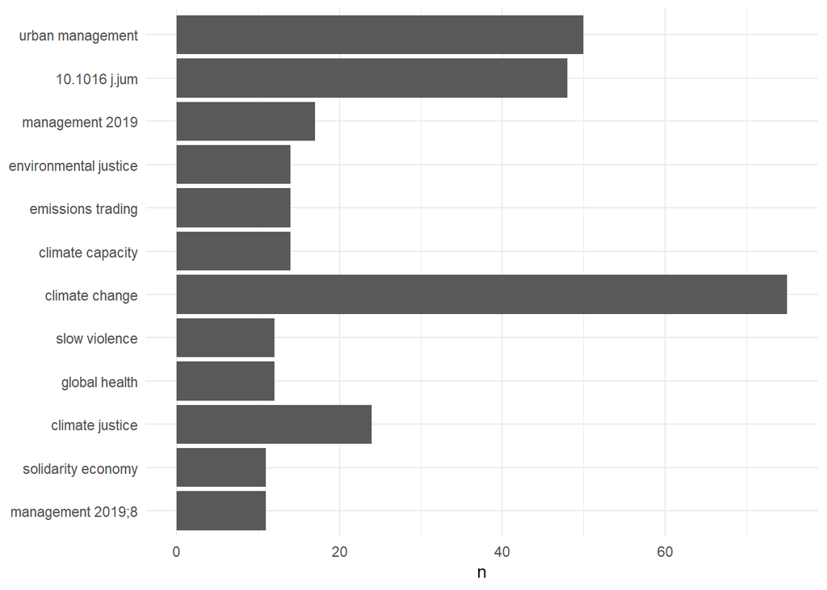

# TO DO

## Author collaboration netrowk

Not sure how to do this yet. George has some code in dropbox I need to have a look at

## Futher analysis (ordination…?)

## Countries publishing most

## Countries most often mentioned in abstracts/keywords?

## Analysis within topic (LDA possible within the given topic?)

## Look at Finn and Georges Janky code